# Lab5

Molly Carrick

11/2/2020

```r
library(tidyverse)
acc <- read.csv("https://raw.githubusercontent.com/xdaiISU/ds202materials/master/hwlabs/fars2017/accident.csv", stringsAsFactors = FALSE)


per<- read.csv("https://raw.githubusercontent.com/xdaiISU/ds202materials/master/hwlabs/fars2017/person.csv", stringsAsFactors = FALSE)
```

1)Are there some days of the week where more accidents happen than the others (see FARS manual, use variable DAY_WEEK)?

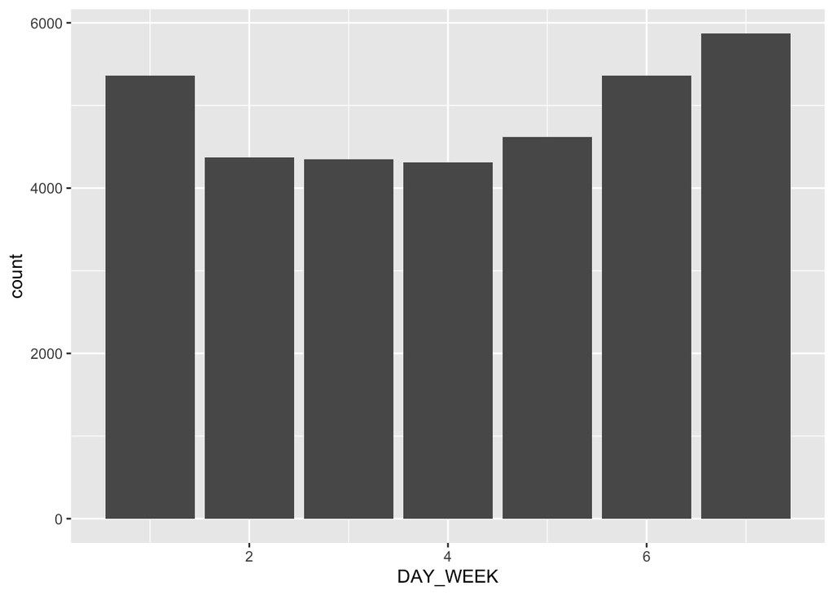

```r
dailyAcc<-acc %>%
  group_by(DAY_WEEK)%>%
  ggplot(aes(x=DAY_WEEK))+geom_bar()

dailyAcc
```

Create a data frame containing the persons who are fatally hurt in the accidents (look up variable INJ_SEV) (Fatal Injury is a 4)

```r
fatal<-per%>%
  filter(INJ_SEV==4)
```

Create a data frame containing the most dangerous vehicle make in each state. The number of persons fatally hit in the vehicle make is used to assess the (non-)safety of a make. Make sure to handle the missing values appropriately. (look up variable MAKE)

```r
danger<-fatal%>%
  group_by(STATE,MAKE)%>%
  summarize(n=n())%>%
  group_by(STATE)%>%
  filter(n==max(n))


head(danger)
```

```
## # A tibble: 6 x 3
## # Groups:   STATE [6]
##   STATE  MAKE     n
##   <int> <int> <int>
## 1     1    12   138
## 2     2    NA    17
## 3     4    NA   261
## 4     5    20    88
## 5     6    NA  1012
## 6     8    NA   108
```

The Most Dangerous Makes are 20,12,37,49,72 overall

4)Create a map, and label each state with the most dangerous vehicle. Discuss the definition of the most dangerous vehicle, and what you find from the map. (Hint: Read the description for the STATE and COUNTY columns in the FARS manual. The state & county codes are Geographic Locator Codes (GLCs) from the General Services Administration’s (GSA) publication. Use readxl::read_xlsx to read in the GLCs.)

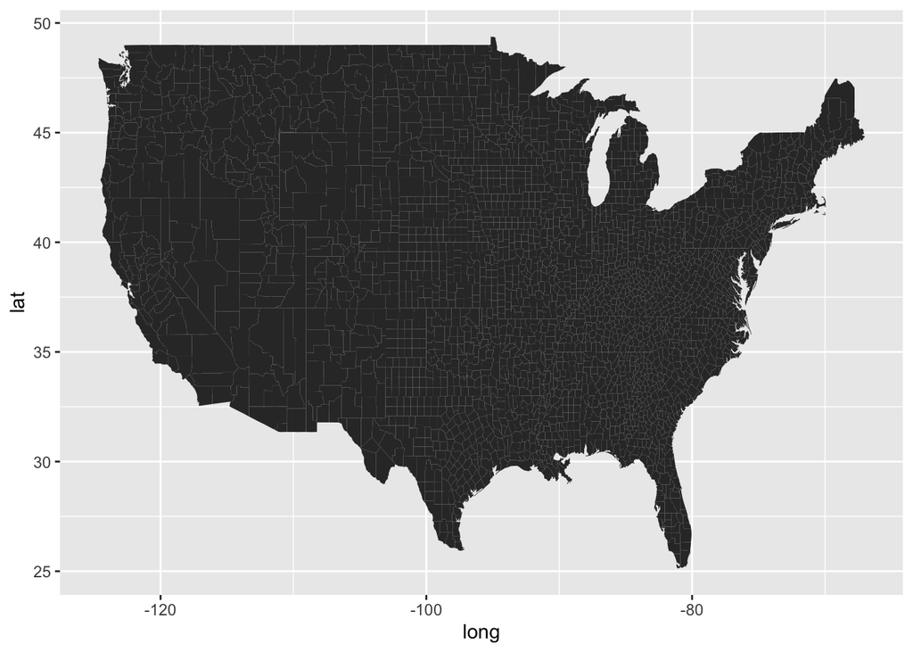

```r
library(maps)
states<-map_data("state")
counties<-map_data("county")

counties%>%
  ggplot(aes(x=long, y=lat, group=group))+geom_polygon()
```

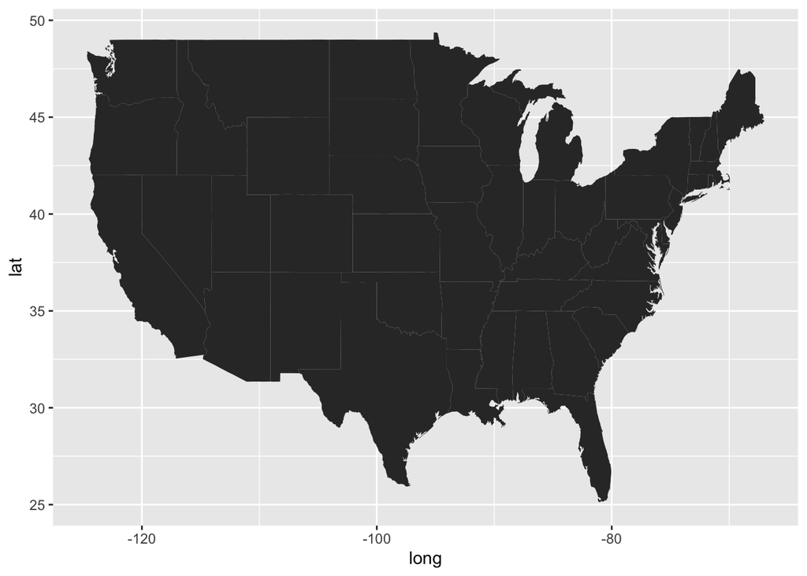

```r
states%>%
  ggplot(aes(x=long, y=lat, group=group))+geom_polygon()
```

```r
glc<-readxl::read_xlsx("FRPP_GLC_-_United_StatesSep292020.xlsx")
#State code ==state

terr<-readxl::read_xlsx("FRPP_GLC_US_TerritoriesSept152020(1).xlsx")
```

```
## * `` -> ...2
## * `` -> ...3
## * `` -> ...4
## * `` -> ...5
## * `` -> ...6
## * ...
```

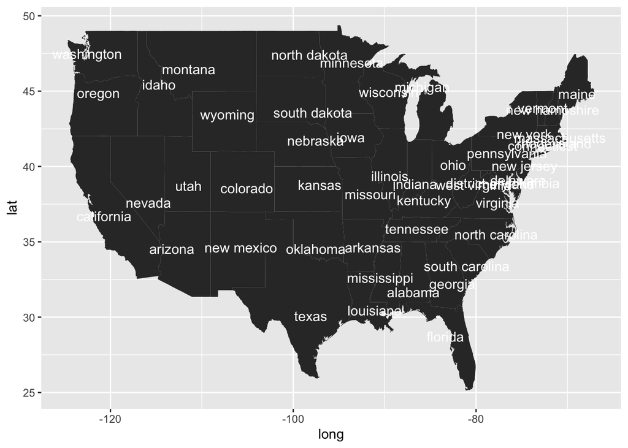

```r
stateName<-states%>%
  group_by(region)%>%
  summarize(long=mean(long),lat=mean(lat))

states%>%
  ggplot(aes(x=long, y=lat))+
  geom_polygon(aes(group=group))+
  geom_text(aes(label=region),color='white', data=stateName)
```

```r
##add Make to stateName by region
##format glc
stateCodes<-glc%>%
  select(c(`State Name`, `State Code`))%>%
  group_by(`State Name`)%>%
  summarize(STATE=max(`State Code`))%>%
  mutate(STATE=as.numeric(STATE))

stateCodes$`State Name`<-tolower(stateCodes$`State Name`)

##combine state codes and danger by STATE
comb<-stateCodes%>%
  left_join(danger)
#combine comb and stateName by region to get make column into stateName
formattedComb<-comb%>%
  select(c(`State Name`, MAKE))%>%
  rename(region=`State Name`)

newStateName<-stateName%>%
  left_join(formattedComb)
```

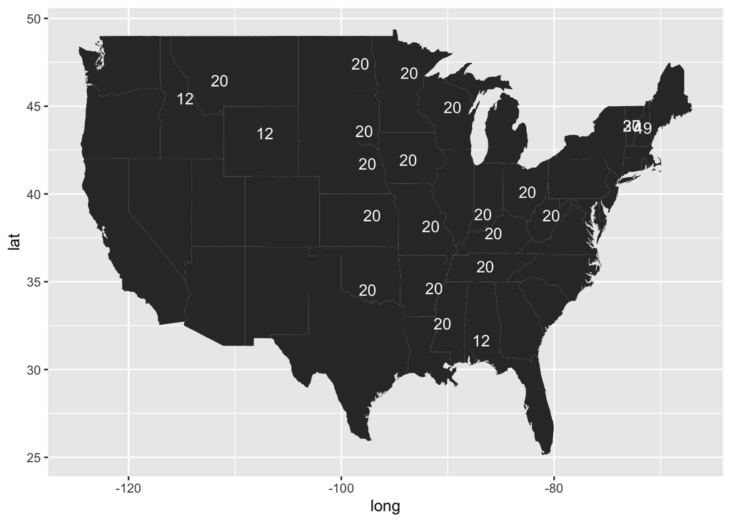

```r
##graph with newStateName


states%>%
  ggplot(aes(x=long, y=lat))+
  geom_polygon(aes(group=group))+
  geom_text(aes(label=MAKE),color='white', data=newStateName)
```

```r
##include territories? get make names?
```

5)Join the accident and person table (work out which variable(s) to use)

```r
##STATE, ST_CASE
joined<-acc%>%
  left_join(per)
```

6)Tally the number of accidents by day of the week (DAY_WEEK), hour of the day (HOUR) and gender (SEX). Visualize the results.

```r
table(joined$DAY_WEEK)
```

```
##
##     1     2     3     4     5     6     7
## 13360 10671 10571 10464 11311 13634 14910
```

```r
table(joined$HOUR)
```

```
##
##    0    1    2    3    4    5    6    7    8    9   10   11   12   13   14   15
## 2928 2540 2735 2096 1706 2269 2880 2824 2183 2301 2719 2952 3716 3888 4223 4839
##   16   17   18   19   20   21   22   23   99
## 4828 5268 5409 4748 4967 4802 4114 3578  408
```

```r
table(joined$SEX)
```

```
##
##     1     2     8     9
## 55230 28149   473  1069
```

7)Now plot a choropleth map of the number of deaths on a county level.

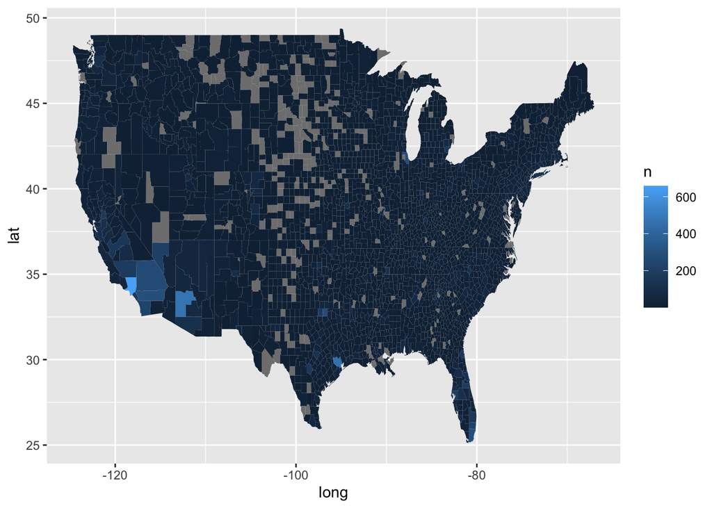

```r
##faily similar based off fatal==4 counties with county map

##deaths per county state
death<-fatal%>%
  group_by(STATE,COUNTY)%>%
  summarize(n=n())

####add county to stateName by region
##format glc
countyCodes<-glc%>%
  select(c(`State Name`, `State Code`, `County Code`,`County Name`))%>%
  group_by(`State Name`,`County Name`)%>%
  summarize(STATE=max(`State Code`), COUNTY=max(`County Code`))%>%
  mutate(STATE=as.numeric(STATE), COUNTY=as.numeric(COUNTY))

countyCodes$`State Name`<-tolower(countyCodes$`State Name`)
countyCodes$`County Name`<-tolower(countyCodes$`County Name`)

##combine state codes and danger by STATE
##did this opposite left join
joinC<-death%>%
  left_join(countyCodes)
countyName<-counties%>%
  group_by(region,subregion)%>%
  summarize(long=mean(long),lat=mean(lat))

formattedJoinC<-joinC%>%
  rename(region=`State Name`, subregion=`County Name`)

newCountyName<-formattedJoinC%>%
  left_join(countyName)
############################# make it a chloreopath!!




 letsgo<-newCountyName%>%
   select(region,subregion,n)
 afterletsgo<-counties%>%
   left_join(letsgo)
 ggplot(afterletsgo, aes(x=long, y=lat, fill=n)) +
  geom_polygon(aes(group=group))
```

[figure not shown]

```r
counties%>%
  ggplot(aes(x=long, y=lat))+
  geom_polygon(aes(group=group))+
  geom_text(aes(label=n),color='white',data=newCountyName)
```

8)Is summer or winter more dangerous? Does this depend on states? Explore and explain.

##chloropath map w/states filter summer, then filter winter

```r
months<-fatal%>%
  group_by(STATE,MONTH)%>%
  summarize(n=n())

winter<-months%>%
  filter(MONTH%in%c(12,1,2,3))

summer<-months%>%
  filter(MONTH%in%c(6,7,8,9))

##total number of accidents per winter/summer by state
winterS<-winter%>%
  group_by(STATE)%>%
  summarize(num=sum(n))

summerS<-summer%>%
  group_by(STATE)%>%
  summarize(num=sum(n))


winterStates<-winterS%>%
  left_join(stateCodes)%>%
  rename(region=`State Name`)
summerStates<-summerS%>%
  left_join(stateCodes)%>%
  rename(region=`State Name`)
thisWinter<-states%>%
  left_join(winterStates)
thisSummer<-states%>%
  left_join(summerStates)
```

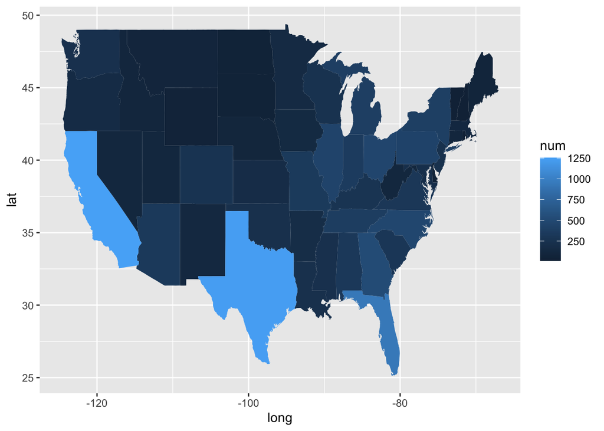

```r
 ggplot(thisSummer, aes(x=long, y=lat, fill=num)) +
  geom_polygon(aes(group=group))
```

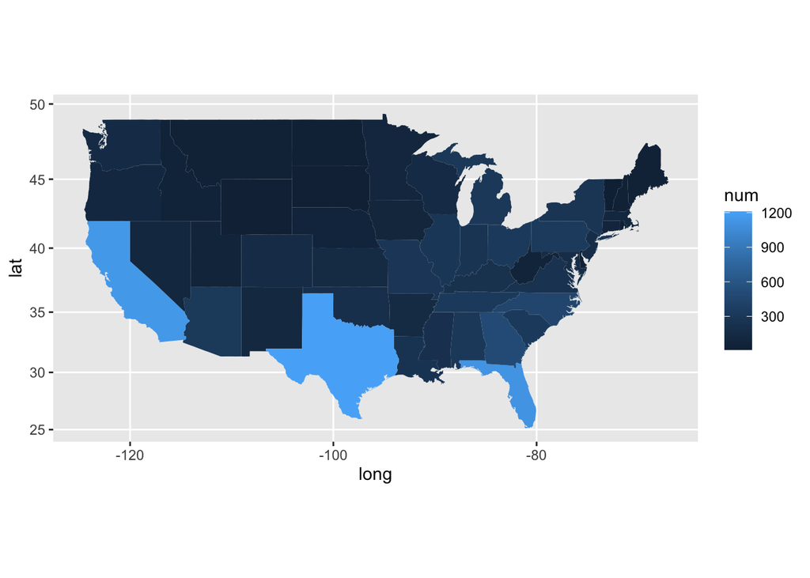

```r
library(mapproj)
ggplot(thisWinter, aes(x=long, y=lat, fill=num)) +
  geom_polygon(aes(group=group))+coord_map()
```

##How to best Join Data Frames? ##How to get model names? ##Territories?